# 01g. Single-end UNITE database comparison

Complete forward · Cutadapt vs ITSxpress · Fungi-only vs All-eukaryotes

2026-10-19

# 1 분석 목적과 주의점

동일한 complete-forward single-end DADA2 ASV에 두 UNITE classifier를 적용하여 database 선택만으로 taxonomy와 downstream fungal table이 얼마나 달라지는지 비교하였다.

- **UNITE 99% Fungi:** 기존 fungi-only classifier
- **UNITE Dynamic All-euk:** 새 All-eukaryotes classifier
- **Methods:** Cutadapt Single, ITSxpress Single
- **고정 조건:** QC20, DADA2 maxEE 2, 동일 feature table 및 동일 representative sequences
- rarefaction, abundance filtering 및 decontam은 적용하지 않았다.

중요하게도 기존 DB는 `99% fungi-only`, 새 DB는 `dynamic all-eukaryotes`이다. 따라서 kingdom 수준의 fungal/non-fungal 전환은 database scope 변화의 직접적인 근거가 되지만, genus/species label의 세부 변화에는 **taxon scope와 clustering 방식의 효과가 함께 포함**된다.

# 2 전체 변화

## 2.1 Method별 요약

| Method | Total_ASVs | AllDB_Fungal_ASVs | AllDB_Fungal_Reads | AllDB_Nonfungal_ASVs | AllDB_Nonfungal_Reads | AllDB_Unassigned_ASVs | Label_Changed_ASVs | Median_Confidence_FungiDB | Median_Confidence_AllDB | Total_Reads | Fungal_Read_Retention | Nonfungal_Read_Fraction |
| --- | --- | --- | --- | --- | --- | --- | --- | --- | --- | --- | --- | --- |
| Cutadapt Single | 1855 | 1265 | 1030316 | 190 | 118237 | 400 | 719 | 0.9971964084051276 | 0.9476293625861384 | 1186913 | 86.81% | 9.96% |
| ITSxpress Single | 211 | 207 | 115517 | 0 | 0 | 4 | 40 | 0.9747789900832308 | 0.9836211777277688 | 115907 | 99.66% | 0.00% |

두 DB는 같은 ASV table에 적용되므로 분류 전 total ASV와 total read 수는 DB에 따라 변하지 않는다. 차이는 All-euk DB로 kingdom을 다시 판정한 뒤 `Fungi`만 유지할 때 발생한다.

## 2.2 All-euk DB의 kingdom 구성

### 2.2.1 Relative abundance

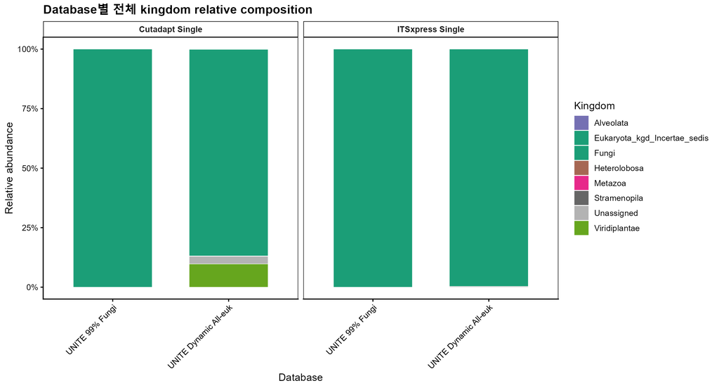

| Method | AllDB_Kingdom | ASVs | Reads | ASV_Fraction | Read_Fraction |
| --- | --- | --- | --- | --- | --- |
| Cutadapt Single | Alveolata | 7 | 1406 | 0.38% | 0.12% |
| Cutadapt Single | Eukaryota_kgd_Incertae_sedis | 1 | 49 | 0.05% | 0.00% |
| Cutadapt Single | Fungi | 1265 | 1030316 | 68.19% | 86.81% |
| Cutadapt Single | Heterolobosa | 1 | 41 | 0.05% | 0.00% |
| Cutadapt Single | Metazoa | 2 | 224 | 0.11% | 0.02% |
| Cutadapt Single | Stramenopila | 8 | 841 | 0.43% | 0.07% |
| Cutadapt Single | Unassigned | 400 | 38360 | 21.56% | 3.23% |
| Cutadapt Single | Viridiplantae | 171 | 115676 | 9.22% | 9.75% |
| ITSxpress Single | Fungi | 207 | 115517 | 98.10% | 99.66% |
| ITSxpress Single | Unassigned | 4 | 390 | 1.90% | 0.34% |

ASV fraction과 read fraction을 함께 봐야 한다. 많은 non-fungal ASV가 모두 고풍부인 것은 아니며, 소수의 고풍부 off-target ASV가 read fraction을 크게 좌우할 수도 있다.

# 3 Database에 따른 taxonomy 변화

## 3.1 Kingdom, Phylum 및 Genus label 변화율

### 3.1.1 ASV 기준

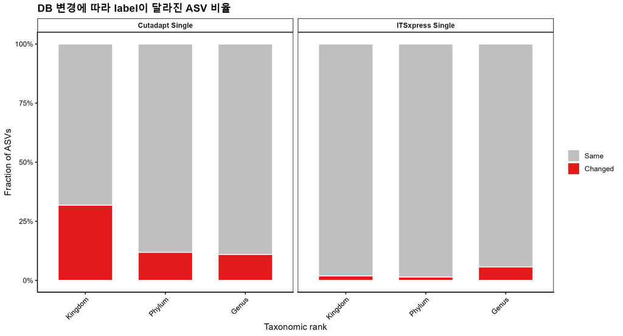

| Method | Rank | Change_Status | ASVs | ASV_Fraction |
| --- | --- | --- | --- | --- |
| Cutadapt Single | Kingdom | Changed | 590 | 31.81% |
| Cutadapt Single | Kingdom | Same | 1265 | 68.19% |
| ITSxpress Single | Kingdom | Changed | 4 | 1.90% |
| ITSxpress Single | Kingdom | Same | 207 | 98.10% |
| Cutadapt Single | Phylum | Changed | 220 | 11.86% |
| Cutadapt Single | Phylum | Same | 1635 | 88.14% |
| ITSxpress Single | Phylum | Changed | 3 | 1.42% |
| ITSxpress Single | Phylum | Same | 208 | 98.58% |
| Cutadapt Single | Genus | Changed | 203 | 10.94% |
| Cutadapt Single | Genus | Same | 1652 | 89.06% |

[output cut: 2 more lines]

`Changed`는 해당 rank의 문자열 label이 달라진 ASV를 의미한다. 특히 Genus 변화에는 `99%`와 `dynamic` clustering 차이도 포함된다.

| Method | Rank | Old_Label | New_Label | ASVs | Reads | Read_Fraction_Within_Rank |
| --- | --- | --- | --- | --- | --- | --- |
| Cutadapt Single | Genus | Unassigned | Raphanus | 23 | 84450 | 69.44% |
| Cutadapt Single | Genus | Unassigned | Brassica | 22 | 20794 | 17.10% |
| Cutadapt Single | Genus | Unassigned | Solanaceae_gen_Incertae_sedis | 2 | 3337 | 2.74% |
| Cutadapt Single | Genus | Unassigned | Cladosporium | 6 | 1773 | 1.46% |
| Cutadapt Single | Genus | Unassigned | Ciliophora_gen_Incertae_sedis | 4 | 1109 | 0.91% |
| Cutadapt Single | Genus | Unassigned | Curvularia | 2 | 1039 | 0.85% |
| Cutadapt Single | Genus | Unassigned | Humulus | 1 | 953 | 0.78% |
| Cutadapt Single | Genus | Fungi_gen_Incertae_sedis | Unassigned | 2 | 882 | 0.73% |
| Cutadapt Single | Genus | Unassigned | Peronospora | 2 | 781 | 0.64% |
| Cutadapt Single | Genus | Unassigned | Prunus | 8 | 714 | 0.59% |

[output cut: 39 more lines]

## 3.2 Kingdom transition

| Method | Kingdom_Transition | ASVs | Reads | Read_Fraction | ASV_Fraction |
| --- | --- | --- | --- | --- | --- |
| Cutadapt Single | Fungi → Alveolata | 7 | 1406 | 0.12% | 0.38% |
| Cutadapt Single | Fungi → Eukaryota_kgd_Incertae_sedis | 1 | 49 | 0.00% | 0.05% |
| Cutadapt Single | Fungi → Fungi | 1265 | 1030316 | 86.81% | 68.19% |
| Cutadapt Single | Fungi → Heterolobosa | 1 | 41 | 0.00% | 0.05% |
| Cutadapt Single | Fungi → Metazoa | 2 | 224 | 0.02% | 0.11% |
| Cutadapt Single | Fungi → Stramenopila | 8 | 841 | 0.07% | 0.43% |
| Cutadapt Single | Fungi → Unassigned | 400 | 38360 | 3.23% | 21.56% |
| Cutadapt Single | Fungi → Viridiplantae | 171 | 115676 | 9.75% | 9.22% |
| ITSxpress Single | Fungi → Fungi | 207 | 115517 | 99.66% | 98.10% |
| ITSxpress Single | Fungi → Unassigned | 4 | 390 | 0.34% | 1.90% |

fungi-only classifier에서는 입력 ASV가 진균 reference 안에서만 경쟁한다. 따라서 `k__Fungi`에 머문 ASV가 All-euk DB에서 식물 또는 다른 진핵생물로 이동하면, 이는 기존의 낮은-rank fungal label이 실제 진균 증거가 아니었을 가능성을 강하게 지지한다.

## 3.3 Taxonomic resolution transition

| Method | Deepest_Rank_Fungi | Deepest_Rank_All | Reads | Read_Fraction |
| --- | --- | --- | --- | --- |
| Cutadapt Single | Species | Species | 809783 | 68.23% |
| Cutadapt Single | Genus | Genus | 137207 | 11.56% |
| Cutadapt Single | Kingdom | Species | 89201 | 7.52% |
| Cutadapt Single | Kingdom | Unassigned | 38068 | 3.21% |
| Cutadapt Single | Family | Family | 22748 | 1.92% |
| Cutadapt Single | Phylum | Species | 18654 | 1.57% |
| Cutadapt Single | Phylum | Phylum | 14135 | 1.19% |
| Cutadapt Single | Order | Order | 13194 | 1.11% |
| Cutadapt Single | Species | Genus | 10744 | 0.91% |
| Cutadapt Single | Genus | Species | 10007 | 0.84% |

[output cut: 47 more lines]

세부 rank 변화는 All-euk 범위뿐 아니라 `99%` 대 `dynamic` clustering 차이도 반영한다. 따라서 species label의 증감은 database 성능의 단순 우열이 아니라 개별 ASV 검증 대상으로 해석한다.

## 3.4 전체 샘플의 DB 전후 Phylum-level taxonomic composition

Phylum 색은 `RColorBrewer::Paired`의 고유색을 그대로 사용했다.

### 3.4.1 Cutadapt Single — UNITE 99% Fungi

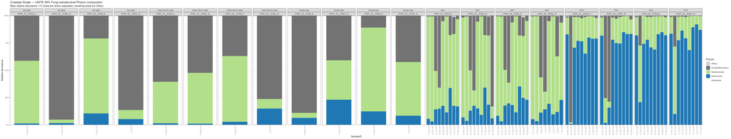

### 3.4.2 Cutadapt Single — UNITE Dynamic All-euk

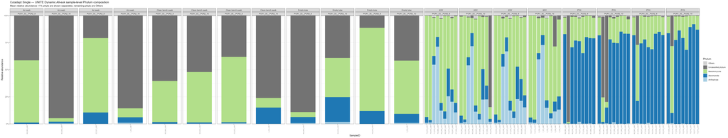

### 3.4.3 ITSxpress Single — UNITE 99% Fungi

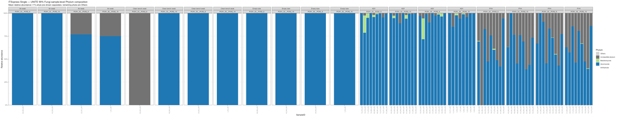

### 3.4.4 ITSxpress Single — UNITE Dynamic All-euk

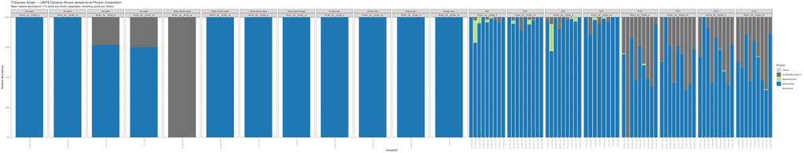

`01_Preprocessing_2.html`의 taxonomy composition 형식을 적용했다. 각 SampleID의 전체 read를 기준으로 한 relative composition이며, **x축은 SampleID**, facet은 `Subject/control source × PCR cycle`, `nrow = 1`이다. Cutadapt/ITSxpress와 taxonomy DB 전후를 각각 분리하여 동일한 Phylum 색을 사용했다. 평균 relative abundance가 1%를 넘는 phylum만 개별 색으로 표시하고 나머지는 `Others`, phylum까지 분류되지 않은 read는 `Unclassified phylum`으로 묶었다. Raw read count 그림은 포함하지 않았다.

## 3.5 전체 샘플의 DB 전후 Fungal Genus-level composition

아래 그림은 각 DB에서 `Kingdom == Fungi`인 read만 남긴 후, sample별 fungal read 합을 분모로 다시 계산한 Genus relative composition이다. Phylum 그림과 동일하게 x축은 SampleID이고 facet은 `Subject/control source × PCR cycle`, `nrow = 1`이다.

### 3.5.1 Cutadapt Single — UNITE 99% Fungi

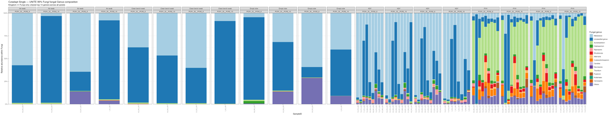

### 3.5.2 Cutadapt Single — UNITE Dynamic All-euk

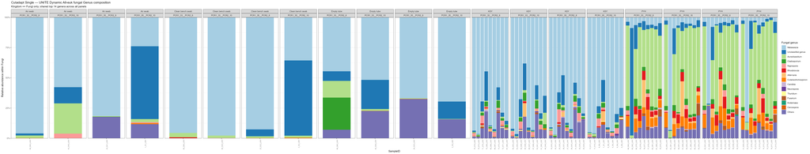

### 3.5.3 ITSxpress Single — UNITE 99% Fungi

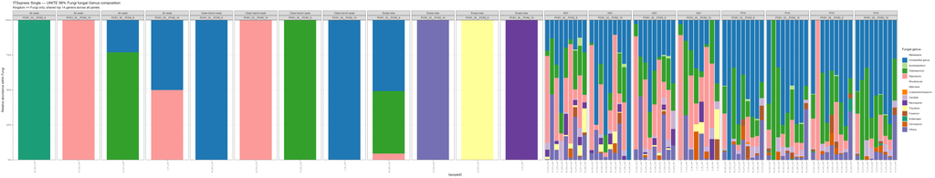

### 3.5.4 ITSxpress Single — UNITE Dynamic All-euk

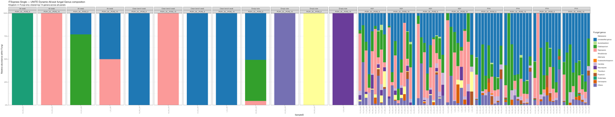

`01f_complete_forward_Cutadapt_vs_ITSxpress.html`과 동일한 composition 선정 규칙을 적용했다. 네 패널(Cutadapt/ITSxpress × DB 전후)의 sample-level fungal relative abundance를 합쳐 평균이 높은 **공통 Top 14 Genus**를 선정하고 나머지는 `Others`로 묶었다. 모든 그림에 동일한 `RColorBrewer` Paired/Dark2 색을 사용하므로 같은 genus는 항상 같은 색이다.

## 3.6 Species-level Bray–Curtis 및 Jaccard PCoA

각 DB에서 `Kingdom == Fungi`만 남기고 `01f`와 동일한 deepest-rank fallback 방식으로 Species label을 만든 뒤 분석했다. Bray–Curtis는 sample별 fungal Species relative abundance, Jaccard는 동일 table의 presence/absence를 사용했다. 같은 SampleID의 두 DB 결과는 회색 선으로 연결했으며 점의 색은 DB, 모양은 대상자/control source이다.

### 3.6.1 Cutadapt Single

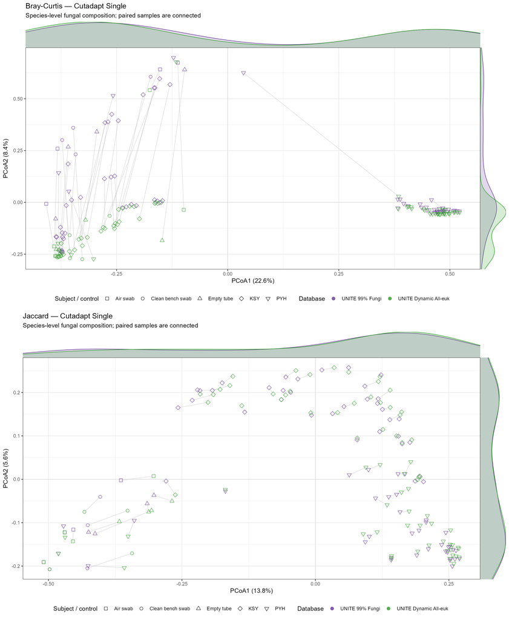

### 3.6.2 ITSxpress Single

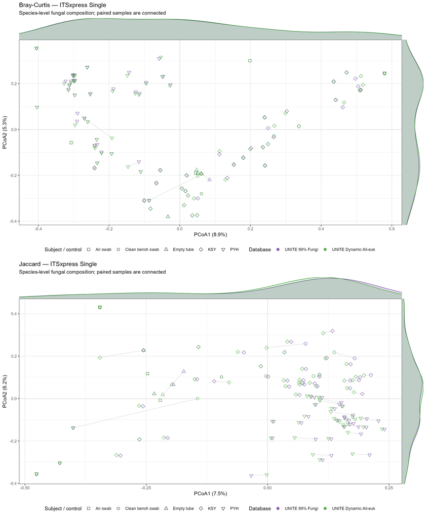

| Method | Distance | N_Paired_Samples | PERMANOVA_R2 | PERMANOVA_P | Median_Paired_Distance | Q1_Paired_Distance | Q3_Paired_Distance | PERMANOVA_P_BH |
| --- | --- | --- | --- | --- | --- | --- | --- | --- |
| Cutadapt Single | Bray-Curtis | 83 | 0.0382 | 0.001 | 0.0723 | 0.0355 | 0.3227 | 0.001 |
| Cutadapt Single | Jaccard | 83 | 0.0162 | 0.001 | 0.1698 | 0.1364 | 0.2206 | 0.001 |
| ITSxpress Single | Bray-Curtis | 83 | 0.0153 | 0.001 | 0.067 | 0.0186 | 0.1186 | 0.001 |
| ITSxpress Single | Jaccard | 83 | 0.0343 | 0.001 | 0.25 | 0.1255 | 0.3333 | 0.001 |

PERMANOVA는 동일 SampleID 안에서 DB label만 교환하는 paired permutation을 사용했다. 그러나 DB에 의해 Species label 자체가 재정의되므로 p-value만으로 생물학적 군집 차이라고 해석하지 않고, paired distance와 PCoA 이동 크기를 database sensitivity로 해석한다.

## 3.7 Classifier confidence

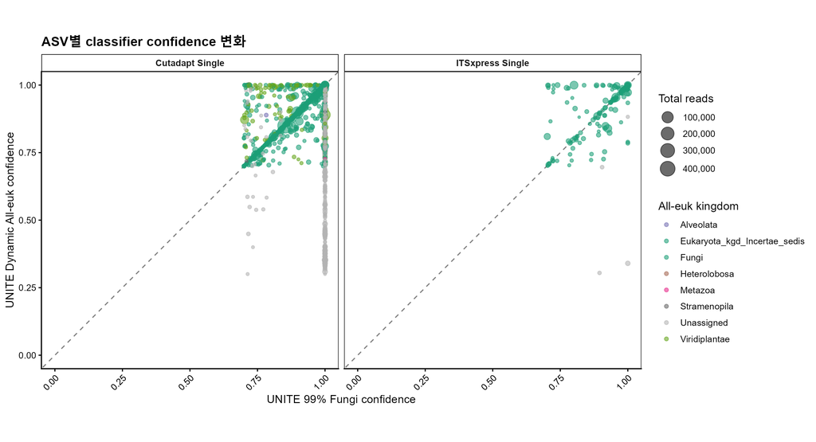

Confidence가 높아졌다는 사실만으로 taxonomy가 참이라고 확정할 수는 없다. 특히 동일 ITS 서열을 여러 종이 공유하는 경우 species-level confidence와 BLAST top-hit 특이성은 별개의 문제이다.

# 4 Fungal read retention의 sample별 변화

## 4.1 동일 sample paired 비교

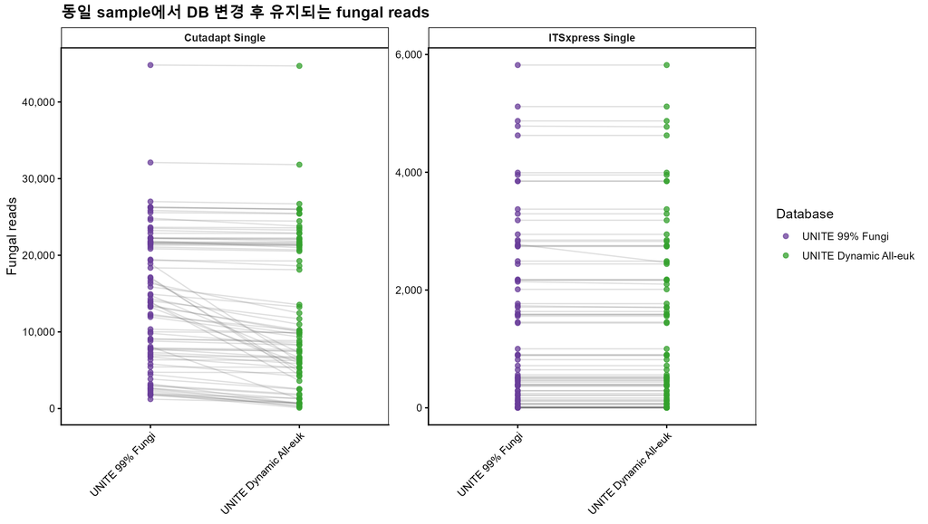

| Method | N | Median_Reads_FungiDB | Median_Reads_AllDB | Median_ASVs_FungiDB | Median_ASVs_AllDB | Read_P | ASV_P |
| --- | --- | --- | --- | --- | --- | --- | --- |
| Cutadapt Single | 83 | 13873 | 9692 | 58 | 46 | 2.55e-15 | 2.48e-15 |
| ITSxpress Single | 83 | 716 | 716 | 12 | 12 | 0.1 | 0.0947 |

Wilcoxon 검정은 database 변경에 따른 deterministic paired difference를 요약한 것이며 biological group difference 검정이 아니다. 따라서 p-value보다 감소 규모와 어떤 ASV가 제외되었는지를 우선 해석한다.

## 4.2 감소 상위 sample의 DB별 taxonomy composition

### 4.2.1 Cutadapt Single

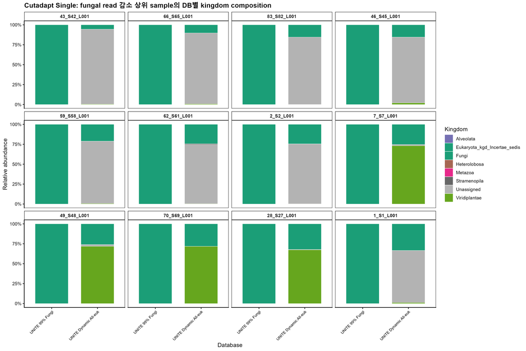

### 4.2.2 ITSxpress Single

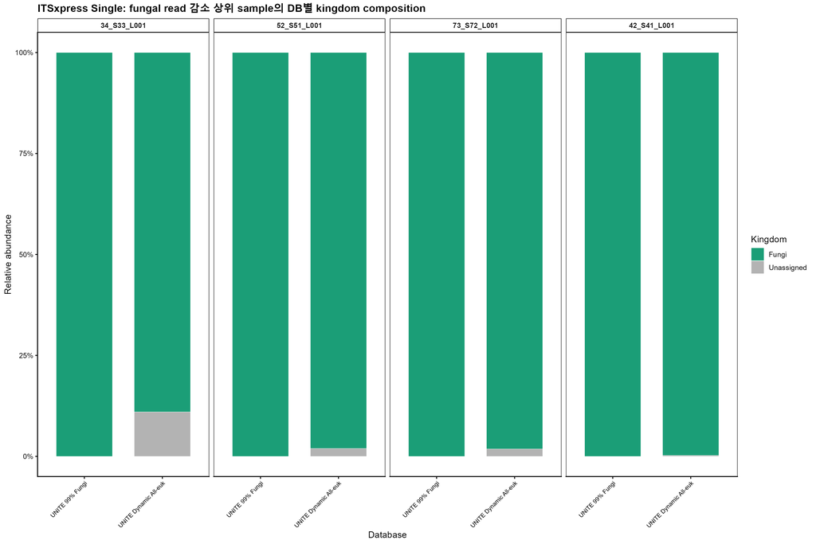

각 facet이 하나의 SampleID이고 x축은 database이다. fungi-only DB에서 전부 또는 거의 전부 Fungi였던 read가 All-euk DB에서 어느 kingdom으로 이동하는지 직접 보여준다. Cutadapt와 ITSxpress는 원래 ASV pool과 read depth가 다르므로 별도 그림으로 제시했다.

## 4.3 PCR condition과 sample type

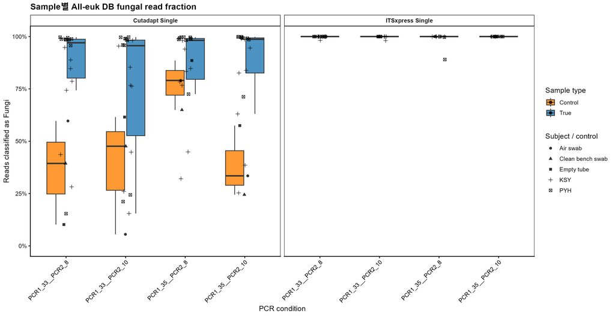

All-euk DB에서 fungal fraction이 낮아지는 sample이 특정 대상자, control type 또는 PCR condition에 집중되는지 확인한다. 이 그림의 감소는 read 제거가 아니라 **같은 ASV read의 kingdom 재분류**를 뜻한다.

# 5 주요 재분류 ASV

## 5.1 고풍부 non-fungal 또는 unassigned ASV

| Method | FeatureID | ASV | Length | Total_Reads | Prevalence | Fungi_DB | All_euk_DB | All_euk_Kingdom | Confidence_Fungi | Confidence_All |
| --- | --- | --- | --- | --- | --- | --- | --- | --- | --- | --- |
| Cutadapt Single | 5c8f111a2f4a8e9e41a1cb58ebc985f6 | 5c8f111a2f | 281 | 68588 | 62 | Fungi (kingdom) | Raphanus sativus | Viridiplantae | 1 | 0.89 |
| Cutadapt Single | 26b3954ec9f864a3279d1281e05aeca9 | 26b3954ec9 | 280 | 16835 | 32 | Ascomycota (phylum) | Brassica rapa | Viridiplantae | 0.702 | 0.871 |
| Cutadapt Single | 30bbba7eedbbcfbbfff1174bb2590e19 | 30bbba7eed | 281 | 8087 | 16 | Fungi (kingdom) | Raphanus sativus | Viridiplantae | 1 | 0.88 |
| Cutadapt Single | 80a4943e3aa9e428e5343675d3f43ca3 | 80a4943e3a | 281 | 3964 | 14 | Fungi (kingdom) | Raphanus sativus | Viridiplantae | 1 | 0.908 |
| Cutadapt Single | e66af9bb9b489d2488394e61c86cc200 | e66af9bb9b | 72 | 3415 | 2 | Fungi (kingdom) | Unassigned | Unassigned | 1 | 0.885 |
| Cutadapt Single | 0d3136a4a718b8cfdd537f2ae53ec66a | 0d3136a4a7 | 281 | 3332 | 28 | Ascomycota (phylum) | Solanaceae (family) | Viridiplantae | 0.878 | 0.954 |
| Cutadapt Single | 410c661df356660e2150fdf59ccdf5a5 | 410c661df3 | 280 | 3180 | 13 | Fungi (kingdom) | Brassica rapa | Viridiplantae | 1 | 0.804 |
| Cutadapt Single | 258b7353c25dd422e75ae6c571792c90 | 258b7353c2 | 281 | 2554 | 8 | Fungi (kingdom) | Raphanus sativus | Viridiplantae | 1 | 0.845 |
| Cutadapt Single | 18c7d62982d378414a46512a47a67112 | 18c7d62982 | 85 | 1821 | 3 | Fungi (kingdom) | Unassigned | Unassigned | 1 | 0.353 |
| Cutadapt Single | 43efaf0af45a35de597d2c3818e1846e | 43efaf0af4 | 87 | 1311 | 1 | Fungi (kingdom) | Unassigned | Unassigned | 1 | 0.352 |

[output cut: 24 more lines]

이 표는 All-euk DB에서 `Fungi`가 아닌 kingdom 또는 unassigned로 분류된 ASV를 read 수 기준으로 보여준다. 제거 후보 목록이 아니라 audit 목록이며, 고풍부·결론 영향 ASV는 BLAST로 재확인해야 한다.

## 5.2 BLAST-confirmed Raphanus ASV

| Method | FeatureID | Length | Total_Reads | Prevalence | Fungi_DB | All_euk_DB | Confidence_Fungi | Confidence_All |
| --- | --- | --- | --- | --- | --- | --- | --- | --- |
| Cutadapt Single | 5c8f111a2f4a8e9e41a1cb58ebc985f6 | 281 | 68588 | 62 | k__Fungi | k__Viridiplantae;p__Anthophyta;c__Eudicotyledonae;o__Brassicales;f__Brassicaceae;g__Raphanus;s__Raphanus_sativus;sh__SH1100084.10FU | 0.9999999999999964 | 0.890036464901143 |

`5c8f111a2f4a8e9e41a1cb58ebc985f6`는 fungi-only DB에서 `k__Fungi`에 머물렀지만 All-euk DB에서 `Raphanus sativus`로 분류된다. 이는 기존 BLAST 결과와 일치하며 broad-eukaryote reference가 off-target 검출에 실질적으로 도움이 된 사례이다.

# 6 전체 True sample의 DB 간 taxonomy 이동

기존 fungi-only DB와 All-euk DB 사이에서 전체 True sample의 read가 어떤 taxonomy로 이동하는지를 인터랙티브 flow chart로 표시한다. 링크에 마우스를 올리면 이동한 read 수와 True-sample 내 비율을 확인할 수 있다. Cutadapt와 ITSxpress는 서로 다른 ASV pool이므로 별도 그림으로 제시한다.

## 6.1 Phylum level

### 6.1.1 Cutadapt Single

[interactive chart not shown]

### 6.1.2 ITSxpress Single

[interactive chart not shown]

이 flow chart는 특정 대상자의 `Fungi_k`만 추적하는 대신 모든 True sample read를 포함한다. 흐름은 Phylum 수준의 기술적 재분류를 요약하며, 개별 고풍부 ASV의 최종 동정은 BLAST로 확인해야 한다.

## 6.2 Family level

Family-level flow는 전체 True sample을 동일하게 사용한다. 그림의 가독성을 위해 각 방법에서 fungi-only DB와 All-euk DB 각각 read 수 상위 20 Family를 유지하고 나머지는 `Other families`로 묶었다. Family까지 분류되지 않은 read는 `Unclassified family`로 표시한다.

### 6.2.1 Cutadapt Single

[interactive chart not shown]

### 6.2.2 ITSxpress Single

[interactive chart not shown]

# 7 Cutadapt forward ASV의 ITSx 기본 및 partial 50 비교

ITSx 1.1.3 (`-t F --save_regions ITS2 --preserve T`)를 complete-forward Cutadapt–DADA2 대표 ASV에 적용한 결과다. 기본 설정의 `itsx.ITS2.fasta`와 `--partial 50`의 `itsx.ITS2.full_and_partial.fasta`를 비교하고, 추출 서열에 다시 적용한 두 UNITE DB의 taxonomy를 함께 확인한다. 입력 FASTA의 ID와 실제 염기서열은 기존 Cutadapt `repseq.qza`와 전수 대조한다.

**이 분석은 ASV 생성 후 처리다.** 아래 read 수는 회수된 원래 ASV ID에 연결된 기존 count이며, raw FASTQ trimming 통과 read 수가 아니다. ITSxpress는 DADA2 이전에 처리하므로 두 수치를 같은 단계의 생존율로 해석하지 않는다. 추출 뒤 동일해진 서열은 고유 서열 수를 별도로 세며, 원래 ASV ID와 count를 유지한다.

## 7.1 입력 및 두 조건의 동일성 검증

| Check | Passed |
| --- | --- |
| Input ASV IDs and sequences match Cutadapt repseq | True |
| Default and partial50 ID sets identical | False |
| All shared extracted sequences identical | True |
| Shared ASVs: taxonomy labels identical in both DBs | True |

공통 ASV와 조건별 고유 ASV를 별도로 확인한다. 검증표의 `FALSE`는 해당 동일성 조건이 성립하지 않는다는 뜻이지, 파일 읽기 실패를 의미하지 않는다.

| FeatureID | Status | Total_Reads | Original_Length | Default_Length | Partial50_Length |
| --- | --- | --- | --- | --- | --- |
| 53620dae5dbb80ceb13ef87452d97458 | Default only | 398 | 155 | 47 |  |
| 4dcf6ac8fdb37a57c244ec73a4452dc3 | Default only | 51 | 155 | 47 |  |
| adf499f58135187160ef07afa064e3be | Default only | 48 | 138 | 30 |  |
| 93cd45e79e1f79b41b63311848c43836 | Partial50 only | 30 | 93 |  | 53 |
| 155df6a14ae70107bea3a00b5d98fd42 | Partial50 only | 3 | 209 |  | 169 |
| cb36852619847cba94e902216a791a46 | Partial50 only | 2 | 117 |  | 78 |

기본 설정도 partial 서열을 출력할 수 있으므로 `default = full ITS2`로 정의하지 않는다. `--partial 50`은 추가 출력 파일의 조건이며, 이번 데이터에서 실제 추가 회수가 있었는지는 ID와 서열 비교 결과로 판단한다. 기록된 이전 서버 출력 경로는 `RELOCATION.txt`에 설명된 이동 이력이며, 현재 `ITSx_res` 아래 파일을 사용한다.

## 7.2 ASV 및 기존 read 회수율

| Stage | Original_ASVs | Unique_sequences | Linked_reads | ASV_retention | Read_retention |
| --- | --- | --- | --- | --- | --- |
| Cutadapt input ASVs | 1855 | 1855 | 1186913 | 100.00% | 100.00% |
| ITSx default | 1204 | 1089 | 1024785 | 64.91% | 86.34% |
| ITSx partial50 | 1204 | 1089 | 1024323 | 64.91% | 86.30% |

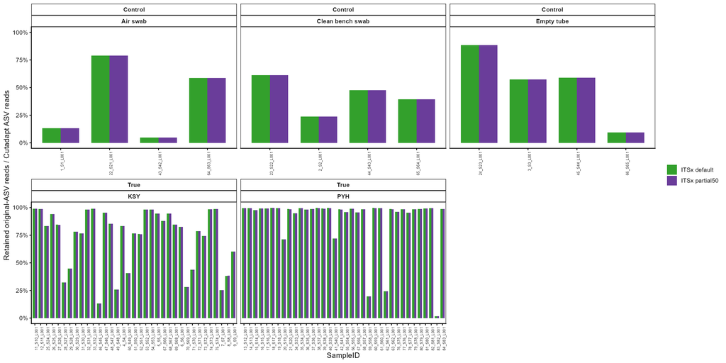

분모는 각 샘플의 전체 Cutadapt–DADA2 ASV read 수다. True/Control/Mock과 대상자·control source를 유지하여 회수율을 확인한다.

## 7.3 경계 상태와 길이 변화

| Status | Boundary | ASVs | Linked_reads |
| --- | --- | --- | --- |
| Both | ITS2 output; incomplete LSU anchor | 1059 | 966930 |
| Both | ITS2 output; inspect positions | 142 | 57358 |
| Default only | ITS2 output; incomplete LSU anchor | 3 | 497 |
| No ITS2 output | No default ITS2 output | 648 | 162093 |
| Partial50 only | No default ITS2 output | 3 | 35 |

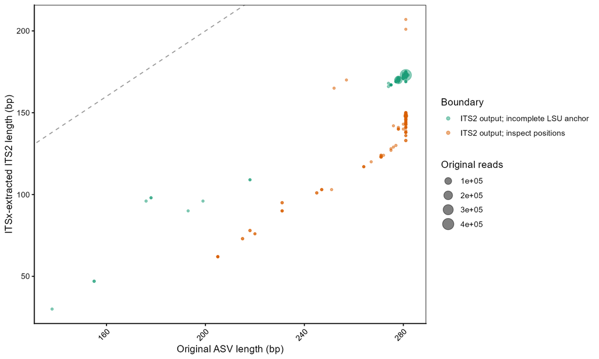

`ITS2 output; incomplete LSU anchor`는 ITS2 출력이 있지만 positions 파일에 LSU 경계가 완전하게 검출되지 않은 경우다. 출력 FASTA만으로 full ITS2라고 간주하지 않는다. 대각선 아래 점은 ITSx 처리로 짧아진 ASV이며, 점 크기는 원래 ASV의 누적 read 수다. 잘려 나간 부분이 primer인지 conserved flank인지는 별도 서열 정렬로 확인해야 한다.

## 7.4 같은 DB에서 ITSx 전후 taxonomy 변화

| Stage | DB | ASVs | Genus_changed_ASVs | Species_changed_ASVs | Fungal_ASVs | Fungal_linked_reads |
| --- | --- | --- | --- | --- | --- | --- |
| ITSx default | UNITE 99% Fungi | 1204 | 116 | 202 | 1204 | 1024785 |
| ITSx default | UNITE Dynamic All-euk | 1204 | 106 | 194 | 1185 | 1023919 |
| ITSx partial50 | UNITE 99% Fungi | 1204 | 116 | 203 | 1204 | 1024323 |
| ITSx partial50 | UNITE Dynamic All-euk | 1204 | 105 | 195 | 1185 | 1023457 |

각 DB 안에서 같은 원래 ASV ID의 trimming 전후 label을 비교한다. 두 DB 간 비교에는 기존과 동일하게 reference scope와 clustering 방식 차이가 함께 포함된다.

| Stage | DB | FeatureID | Total_Reads | Original_Length | Default_Length | Before_Label | Display_Taxon | Genus_changed | Species_changed |
| --- | --- | --- | --- | --- | --- | --- | --- | --- | --- |
| ITSx default | UNITE 99% Fungi | 10e25f6b435d5136e1565c0b20a20cfc | 400005 | 281 | 173 | Aureobasidium tremulum | Fungi (kingdom) | True | True |
| ITSx default | UNITE Dynamic All-euk | 10e25f6b435d5136e1565c0b20a20cfc | 400005 | 281 | 173 | Aureobasidium tremulum | Fungi (kingdom) | True | True |
| ITSx partial50 | UNITE 99% Fungi | 10e25f6b435d5136e1565c0b20a20cfc | 400005 | 281 | 173 | Aureobasidium tremulum | Fungi (kingdom) | True | True |
| ITSx partial50 | UNITE Dynamic All-euk | 10e25f6b435d5136e1565c0b20a20cfc | 400005 | 281 | 173 | Aureobasidium tremulum | Fungi (kingdom) | True | True |
| ITSx default | UNITE 99% Fungi | b4f38aaf269ff08535fc440b5e8e52f8 | 26711 | 281 | 173 | Aureobasidium sp. | Fungi (kingdom) | True | True |
| ITSx default | UNITE Dynamic All-euk | b4f38aaf269ff08535fc440b5e8e52f8 | 26711 | 281 | 173 | Aureobasidium sp. | Fungi (kingdom) | True | True |
| ITSx partial50 | UNITE 99% Fungi | b4f38aaf269ff08535fc440b5e8e52f8 | 26711 | 281 | 173 | Aureobasidium sp. | Fungi (kingdom) | True | True |
| ITSx partial50 | UNITE Dynamic All-euk | b4f38aaf269ff08535fc440b5e8e52f8 | 26711 | 281 | 173 | Aureobasidium sp. | Fungi (kingdom) | True | True |
| ITSx default | UNITE 99% Fungi | a299ef28e148515b0b27ccd380b2cf42 | 12343 | 281 | 148 | Cladosporium herbarum | Cladosporium sp. | False | True |
| ITSx default | UNITE Dynamic All-euk | a299ef28e148515b0b27ccd380b2cf42 | 12343 | 281 | 148 | Cladosporium herbarum | Cladosporium sp. | False | True |

[output cut: 852 more lines]

## 7.5 전체 SampleID별 Genus composition

두 DB별로 원래 Cutadapt, ITSx 기본, ITSx partial50을 같은 색과 순서로 비교한다. **분모는 전부 원래 Cutadapt sample read 수로 고정**한다. 따라서 추출되지 않은 ASV의 read는 `No ITS2 output`으로 표시하며, 회수된 서열만 100%로 재정규화하여 소실을 숨기지 않는다. 비진균 kingdom도 표시한다. 각 행은 처리 조건, 열은 대상자 또는 control source, x축은 SampleID다. 전체 CSV에 PCR 조건과 부위 정보도 보존한다.

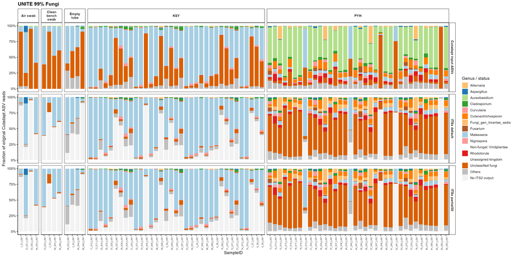

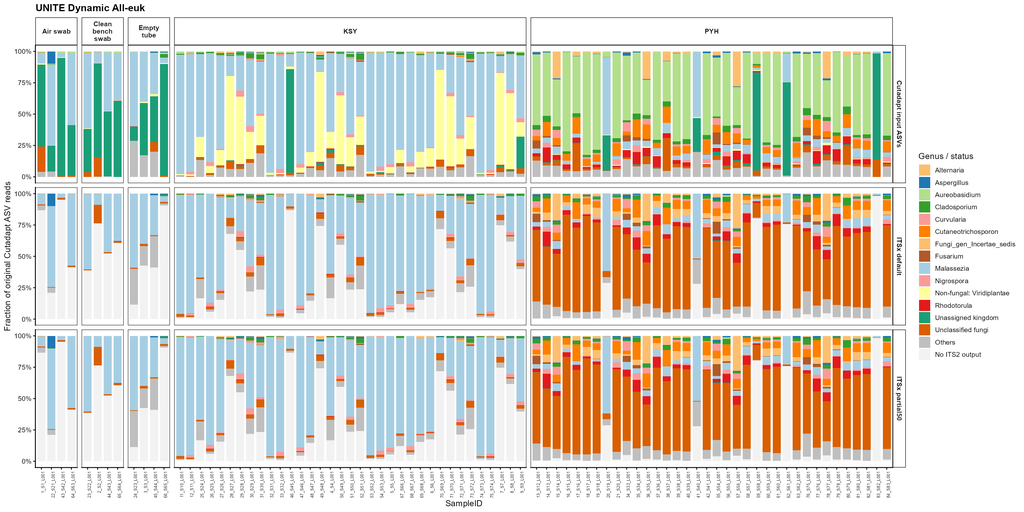

## 7.6 Malassezia, Aureobasidium 및 Raphanus ASV 추적

원래 두 DB 중 하나에서 focal genus로 분류된 ASV를 추적한다. 원래 label과 추출 후 label은 동정 후보이며, 변경된 species label의 정확도는 BLAST/curated reference로 검증해야 한다. `Status`가 `No ITS2 output`인 원본 ASV도 표에 남긴다.

| Stage | DB | FeatureID | Display_Taxon | Kingdom_Group | Total_Reads | Original_Length | Default_Length | Status |
| --- | --- | --- | --- | --- | --- | --- | --- | --- |
| Cutadapt input ASVs | UNITE 99% Fungi | 10e25f6b435d5136e1565c0b20a20cfc | Aureobasidium tremulum | Fungi | 400005 | 281 | 173 | Both |
| ITSx default | UNITE 99% Fungi | 10e25f6b435d5136e1565c0b20a20cfc | Fungi (kingdom) | Fungi | 400005 | 281 | 173 | Both |
| ITSx partial50 | UNITE 99% Fungi | 10e25f6b435d5136e1565c0b20a20cfc | Fungi (kingdom) | Fungi | 400005 | 281 | 173 | Both |
| Cutadapt input ASVs | UNITE Dynamic All-euk | 10e25f6b435d5136e1565c0b20a20cfc | Aureobasidium tremulum | Fungi | 400005 | 281 | 173 | Both |
| ITSx default | UNITE Dynamic All-euk | 10e25f6b435d5136e1565c0b20a20cfc | Fungi (kingdom) | Fungi | 400005 | 281 | 173 | Both |
| ITSx partial50 | UNITE Dynamic All-euk | 10e25f6b435d5136e1565c0b20a20cfc | Fungi (kingdom) | Fungi | 400005 | 281 | 173 | Both |
| Cutadapt input ASVs | UNITE 99% Fungi | 12d20fad470c6affa26d6895f43000f1 | Malassezia restricta | Fungi | 135269 | 278 | 170 | Both |
| ITSx default | UNITE 99% Fungi | 12d20fad470c6affa26d6895f43000f1 | Malassezia restricta | Fungi | 135269 | 278 | 170 | Both |
| ITSx partial50 | UNITE 99% Fungi | 12d20fad470c6affa26d6895f43000f1 | Malassezia restricta | Fungi | 135269 | 278 | 170 | Both |
| Cutadapt input ASVs | UNITE Dynamic All-euk | 12d20fad470c6affa26d6895f43000f1 | Malassezia restricta | Fungi | 135269 | 278 | 170 | Both |

[output cut: 682 more lines]

## 7.7 Aureobasidium의 ITSx 전후 실제 염기서열 정렬

### 7.7.1 전체 Aureobasidium ASV: DB별 Cutadapt–ITSx 분류 및 confidence

Cutadapt에서 Aureobasidium으로 분류된 **전체 10 ASV (428,245 reads)**를 포함한다. 같은 원본 ASV ID의 Cutadapt와 ITSx만 비교하며 **이 표에는 ITSxpress를 포함하지 않는다.** Read 수는 전체 샘플의 원래 Cutadapt count 합계다. 이 10개에서는 ITSx 기본/partial50의 서열, taxonomy 및 confidence가 동일한지 검증했으므로 ITSx 열 하나로 표시한다.

Confidence는 taxonomy.tsv에 기록된 최종 분류의 값이다. 일부 종명 결과에는 SH까지 포함되므로 독립적인 species confidence로 해석하지 않는다. Fungi의 confidence가 1에 가깝다고 해서 해당 ASV가 Aureobasidium이 아니라는 뜻은 아니며, 서로 다른 rank의 confidence를 정확도처럼 직접 비교하지 않는다. 원본 taxonomy 문자열은 CSV에 함께 저장했다.

#### 7.7.1.1 UNITE 99% Fungi

| FeatureID | Total_Reads | Cutadapt_label | Cutadapt_confidence | ITSx_label | ITSx_confidence | BLAST_evidence |
| --- | --- | --- | --- | --- | --- | --- |
| 10e25f6b435d5136e1565c0b20a20cfc | 400005 | Aureobasidium tremulum | 0.852284816015181 | Fungi (kingdom) | 0.9999999999999936 | ASV is exact substring of longer saved query; NOT direct ASV BLAST |
| b4f38aaf269ff08535fc440b5e8e52f8 | 26711 | Aureobasidium sp. | 0.7436035927328783 | Fungi (kingdom) | 0.9962807854730164 | No exact query/containment match |
| 3bfa92476cc05fd6c57650c07c88cf10 | 520 | Aureobasidium sp. | 0.8985429169434767 | Fungi (kingdom) | 0.9806885566430852 | No exact query/containment match |
| f4afe240949d086bdb5a35eae85889a4 | 501 | Aureobasidium pullulans | 0.9608291000677284 | Fungi (kingdom) | 1.000000000000002 | No exact query/containment match |
| 74691e17a7abbf42e25cbac604e92b85 | 204 | Aureobasidium pullulans | 0.9788051159480476 | Fungi (kingdom) | 1.000000000000002 | No exact query/containment match |
| 1841176cb9159f5802e0decea4e44d3f | 180 | Aureobasidium pullulans | 0.9987066834325048 | Aureobasidium pullulans | 0.9968060641336636 | No exact query/containment match |
| 0308b938862a60c3caa5a996c5d10417 | 46 | Aureobasidium sp. | 0.8303784997273274 | Fungi (kingdom) | 0.9806885566430852 | No exact query/containment match |
| 5fff8f302e81cc444cfdfacb119d28d3 | 27 | Aureobasidium pullulans | 0.9939494710926 | Aureobasidium pullulans | 0.98709224514813 | No exact query/containment match |
| 37dcb6297448140a1e9e966a72f82cc2 | 26 | Aureobasidium tremulum | 0.8768957306771858 | Fungi (kingdom) | 0.9999999999999936 | No exact query/containment match |
| a8714773729d340797d55755eb37a3ea | 25 | Aureobasidium pullulans | 0.9961669346786168 | Aureobasidium pullulans | 0.9833997596194008 | No exact query/containment match |

#### 7.7.1.2 UNITE Dynamic All-euk

| FeatureID | Total_Reads | Cutadapt_label | Cutadapt_confidence | ITSx_label | ITSx_confidence | BLAST_evidence |
| --- | --- | --- | --- | --- | --- | --- |
| 10e25f6b435d5136e1565c0b20a20cfc | 400005 | Aureobasidium tremulum | 0.8495617884636225 | Fungi (kingdom) | 0.9999999999661238 | ASV is exact substring of longer saved query; NOT direct ASV BLAST |
| b4f38aaf269ff08535fc440b5e8e52f8 | 26711 | Aureobasidium sp. | 0.7405037961703027 | Fungi (kingdom) | 0.9961106620816128 | No exact query/containment match |
| 3bfa92476cc05fd6c57650c07c88cf10 | 520 | Aureobasidium sp. | 0.8876599554933718 | Fungi (kingdom) | 0.9804248998994084 | No exact query/containment match |
| f4afe240949d086bdb5a35eae85889a4 | 501 | Aureobasidium sp. | 0.997172654846096 | Aureobasidium sp. | 0.7795809965091139 | No exact query/containment match |
| 74691e17a7abbf42e25cbac604e92b85 | 204 | Aureobasidium sp. | 0.9964994659462526 | Fungi (kingdom) | 0.9999999998621384 | No exact query/containment match |
| 1841176cb9159f5802e0decea4e44d3f | 180 | Aureobasidium pullulans | 0.976247301112511 | Aureobasidium pullulans | 0.9815633694429178 | No exact query/containment match |
| 0308b938862a60c3caa5a996c5d10417 | 46 | Aureobasidium sp. | 0.8221646387984691 | Fungi (kingdom) | 0.9804248998994084 | No exact query/containment match |
| 5fff8f302e81cc444cfdfacb119d28d3 | 27 | Aureobasidium pullulans | 0.9666277705165556 | Aureobasidium pullulans | 0.9676296824006688 | No exact query/containment match |
| 37dcb6297448140a1e9e966a72f82cc2 | 26 | Aureobasidium tremulum | 0.8748424751392442 | Fungi (kingdom) | 0.9999999999661238 | No exact query/containment match |
| a8714773729d340797d55755eb37a3ea | 25 | Aureobasidium pullulans | 0.9674820171813138 | Aureobasidium pullulans | 0.9630721369227038 | No exact query/containment match |

#### 7.7.1.3 Batch BLAST–QIIME confidence scatter

`blast_results` 폴더의 **complete-forward Cutadapt 1,855 ASV**와 **complete-forward ITSxpress 211 ASV** batch BLAST 결과를 사용했다. Cutadapt은 위 10개 원본 ASV, ITSxpress는 QIIME 또는 BLAST에서 Aureobasidium이 확인된 9개 별도 ASV다. **두 처리군을 동일 ASV로 연결하지 않는다.** Cutadapt → 외부 ITSx 173 bp는 batch BLAST 결과가 없으므로 이 그림과 표에서 제외했다.

x축은 `percent identity × query coverage / 100`인 coverage-weighted identity, y축은 각 DB에서의 QIIME classifier confidence다. 점 모양은 QIIME의 최종 분류 해상도, 색은 QIIME–BLAST 조정 결과, 크기는 read 수다. 서로 다른 rank에서의 confidence는 정확도처럼 직접 비교하지 않는다.

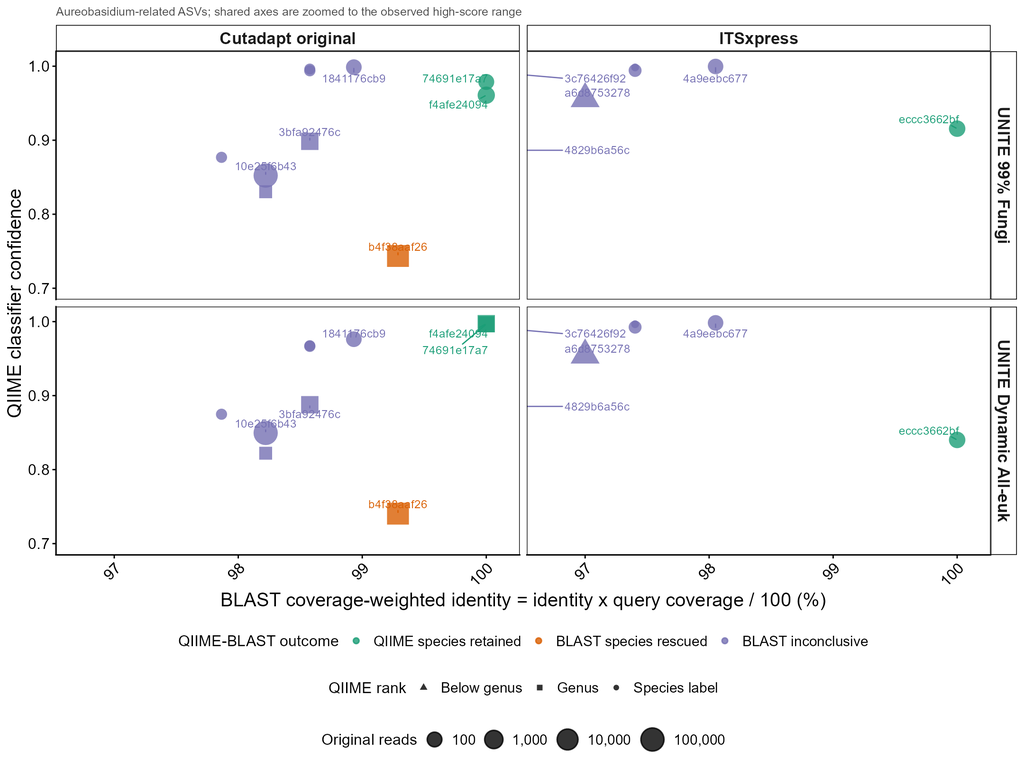

| Processing | DB | FeatureID | Total_Reads | QIIME_Label | QIIME_Confidence | BLAST_Top1_Species | BLAST_Identity | BLAST_Query_Coverage | BLAST_Composite | BLAST_Bitscore | BLAST_Ambiguous | Evidence | Replacement_Status |
| --- | --- | --- | --- | --- | --- | --- | --- | --- | --- | --- | --- | --- | --- |
| Cutadapt original | UNITE 99% Fungi | 10e25f6b435d5136e1565c0b20a20cfc | 400005 | Aureobasidium tremulum | 0.852284816015181 | Aureobasidium_melanogenum | 98.221 | 100 | 98.221 | 483 | False | BLAST inconclusive | qiime_retained_blast_cutoff_fail |
| Cutadapt original | UNITE Dynamic All-euk | 10e25f6b435d5136e1565c0b20a20cfc | 400005 | Aureobasidium tremulum | 0.8495617884636225 | Aureobasidium_melanogenum | 98.221 | 100 | 98.221 | 483 | False | BLAST inconclusive | qiime_retained_blast_cutoff_fail |
| Cutadapt original | UNITE 99% Fungi | b4f38aaf269ff08535fc440b5e8e52f8 | 26711 | Aureobasidium sp. | 0.7436035927328783 | Aureobasidium_melanogenum | 99.288 | 100 | 99.288 | 496 | False | BLAST species rescued | blast_species_rescued_missing_qiime_species |
| Cutadapt original | UNITE Dynamic All-euk | b4f38aaf269ff08535fc440b5e8e52f8 | 26711 | Aureobasidium sp. | 0.7405037961703027 | Aureobasidium_melanogenum | 99.288 | 100 | 99.288 | 496 | False | BLAST species rescued | blast_species_rescued_missing_qiime_species |
| Cutadapt original | UNITE 99% Fungi | 3bfa92476cc05fd6c57650c07c88cf10 | 520 | Aureobasidium sp. | 0.8985429169434767 | Aureobasidium_melanogenum | 98.577 | 100 | 98.57700000000001 | 488 | False | BLAST inconclusive | qiime_retained_blast_cutoff_fail |
| Cutadapt original | UNITE Dynamic All-euk | 3bfa92476cc05fd6c57650c07c88cf10 | 520 | Aureobasidium sp. | 0.8876599554933718 | Aureobasidium_melanogenum | 98.577 | 100 | 98.57700000000001 | 488 | False | BLAST inconclusive | qiime_retained_blast_cutoff_fail |
| Cutadapt original | UNITE 99% Fungi | f4afe240949d086bdb5a35eae85889a4 | 501 | Aureobasidium pullulans | 0.9608291000677284 | Aureobasidium_namibiae | 100 | 100 | 100 | 508 | False | QIIME species retained | qiime_retained_resolved_species |
| Cutadapt original | UNITE Dynamic All-euk | f4afe240949d086bdb5a35eae85889a4 | 501 | Aureobasidium sp. | 0.997172654846096 | Aureobasidium_namibiae | 100 | 100 | 100 | 508 | False | QIIME species retained | qiime_retained_resolved_species |
| Cutadapt original | UNITE 99% Fungi | 74691e17a7abbf42e25cbac604e92b85 | 204 | Aureobasidium pullulans | 0.9788051159480476 | Aureobasidium_xishuangbannaense | 100 | 100 | 100 | 508 | False | QIIME species retained | qiime_retained_resolved_species |
| Cutadapt original | UNITE Dynamic All-euk | 74691e17a7abbf42e25cbac604e92b85 | 204 | Aureobasidium sp. | 0.9964994659462526 | Aureobasidium_xishuangbannaense | 100 | 100 | 100 | 508 | False | QIIME species retained | qiime_retained_resolved_species |

[output cut: 24 more lines]

`BLAST_Composite = NA`는 no-hit을 뜻하지 않는다. ITSx는 아직 BLAST 미실행, ITSxpress의 일부 ASV는 batch 결과에 사용 가능한 species-level top hit가 없는 경우다. 각 ASV의 identity, query coverage, bit score, ambiguity와 분류 보정 상태는 CSV에 보존한다.

### 7.7.2 원서열과 ITSx 추출서열 정렬

기존 DB 중 하나에서 Aureobasidium으로 분류된 ASV 전체를 대상으로, **같은 ASV ID의 원서열과 ITSx 추출서열**을 직접 정렬했다. 분류가 유지된 ASV도 비교 대상으로 포함한다. 이 ITSx 실행은 원래 ASV ID를 보존하므로 서로 다른 ASV를 이름만 보고 연결한 것이 아니다. exact substring을 찾아 원서열 좌표에 배치하며, 각 서열에서 일치 위치가 하나뿐인지 검증한다. 아래 dash는 제거된 구간이며 생물학적 deletion을 뜻하지 않는다.

| FeatureID | Stage | Reads | Original_bp | Extracted_bp | Start_1based | End_1based | Removed_5prime_bp | Removed_3prime_bp | Retained_region_identity_pct | Original_coverage_pct |
| --- | --- | --- | --- | --- | --- | --- | --- | --- | --- | --- |
| 10e25f6b435d5136e1565c0b20a20cfc | Default | 400005 | 281 | 173 | 109 | 281 | 108 | 0 | 100 | 61.56583629893238 |
| 10e25f6b435d5136e1565c0b20a20cfc | Partial50 | 400005 | 281 | 173 | 109 | 281 | 108 | 0 | 100 | 61.56583629893238 |
| b4f38aaf269ff08535fc440b5e8e52f8 | Default | 26711 | 281 | 173 | 109 | 281 | 108 | 0 | 100 | 61.56583629893238 |
| b4f38aaf269ff08535fc440b5e8e52f8 | Partial50 | 26711 | 281 | 173 | 109 | 281 | 108 | 0 | 100 | 61.56583629893238 |
| 3bfa92476cc05fd6c57650c07c88cf10 | Default | 520 | 281 | 173 | 109 | 281 | 108 | 0 | 100 | 61.56583629893238 |
| 3bfa92476cc05fd6c57650c07c88cf10 | Partial50 | 520 | 281 | 173 | 109 | 281 | 108 | 0 | 100 | 61.56583629893238 |
| f4afe240949d086bdb5a35eae85889a4 | Default | 501 | 281 | 173 | 109 | 281 | 108 | 0 | 100 | 61.56583629893238 |
| f4afe240949d086bdb5a35eae85889a4 | Partial50 | 501 | 281 | 173 | 109 | 281 | 108 | 0 | 100 | 61.56583629893238 |
| 74691e17a7abbf42e25cbac604e92b85 | Default | 204 | 281 | 173 | 109 | 281 | 108 | 0 | 100 | 61.56583629893238 |
| 74691e17a7abbf42e25cbac604e92b85 | Partial50 | 204 | 281 | 173 | 109 | 281 | 108 | 0 | 100 | 61.56583629893238 |

[output cut: 10 more lines]

**Identity는 남아 있는 구간의 일치율**, coverage는 원래 길이 중 남아 있는 비율이다. 따라서 retained identity 100%라고 해서 원서열 전체가 보존됐다는 뜻은 아니다. 아래 실제 염기서열은 기본 ITSx 결과이며 partial50과의 비교도 위 표 및 CSV에 포함한다.

**10e25f6b435d5136e1565c0b20a20cfc — 400,005 reads**

UNITE 99% Fungi: Aureobasidium tremulum → Fungi (kingdom)  
UNITE Dynamic All-euk: Aureobasidium tremulum → Fungi (kingdom)

1–70 Cutadapt GAAATGCGATAAGTAATGTGAATTGCAGAATTCAGTGAATCATCGAATCTTTGAACGCACATTGCGCCCC Match  
ITSx ----------------------------------------------------------------------

71–140 Cutadapt TTGGTATTCCGAGGGGCATGCCTGTTCGAGCGTCATTACACCACTCAAGCTATGCTTGGTATTGGGTGCC Match |||||||||||||||||||||||||||||||| ITSx --------------------------------------CACCACTCAAGCTATGCTTGGTATTGGGTGCC

141–210 Cutadapt GTCCTTAGTTGGGCGCGCCTCAAAGACCTCGGCGAGGCCTCACCGGCTTTAGGCGTAGTAGAATTTATTC Match |||||||||||||||||||||||||||||||||||||||||||||||||||||||||||||||||||||| ITSx GTCCTTAGTTGGGCGCGCCTCAAAGACCTCGGCGAGGCCTCACCGGCTTTAGGCGTAGTAGAATTTATTC

211–280 Cutadapt GAACGTCTGTCAAAGGAGAGGACTTCTGCCGACTGAAACCTTTTATTTTTCTAGGTTGACCTCGGATCAG Match |||||||||||||||||||||||||||||||||||||||||||||||||||||||||||||||||||||| ITSx GAACGTCTGTCAAAGGAGAGGACTTCTGCCGACTGAAACCTTTTATTTTTCTAGGTTGACCTCGGATCAG

281–281 Cutadapt G Match | ITSx G

**b4f38aaf269ff08535fc440b5e8e52f8 — 26,711 reads**

UNITE 99% Fungi: Aureobasidium sp. → Fungi (kingdom)  
UNITE Dynamic All-euk: Aureobasidium sp. → Fungi (kingdom)

1–70 Cutadapt GAAATGCGATAAGTAATGTGAATTGCAGAATTCAGTGAATCATCGAATCTTTGAACGCACATTGCGCCCC Match  
ITSx ----------------------------------------------------------------------

71–140 Cutadapt TTGGTATTCCGAGGGGCATGCCTGTTCGAGCGTCATTACACCACTCAAGCTATGCTTGGTATTGGGTGCC Match |||||||||||||||||||||||||||||||| ITSx --------------------------------------CACCACTCAAGCTATGCTTGGTATTGGGTGCC

141–210 Cutadapt GTCCTTAGTTGGGCGCGCCTTAAAGACCTCGGCGAGGCCTCACCGGCTTTAGGCGTAGTAGAATTTATTC Match |||||||||||||||||||||||||||||||||||||||||||||||||||||||||||||||||||||| ITSx GTCCTTAGTTGGGCGCGCCTTAAAGACCTCGGCGAGGCCTCACCGGCTTTAGGCGTAGTAGAATTTATTC

211–280 Cutadapt GAACGTCTGTCAAAGGAGAGGACTTCTGCCGACTGAAACCTTTATTTTTCTAGGTTGACCTCGGATCAGG Match |||||||||||||||||||||||||||||||||||||||||||||||||||||||||||||||||||||| ITSx GAACGTCTGTCAAAGGAGAGGACTTCTGCCGACTGAAACCTTTATTTTTCTAGGTTGACCTCGGATCAGG

281–281 Cutadapt T Match | ITSx T

**3bfa92476cc05fd6c57650c07c88cf10 — 520 reads**

UNITE 99% Fungi: Aureobasidium sp. → Fungi (kingdom)  
UNITE Dynamic All-euk: Aureobasidium sp. → Fungi (kingdom)

1–70 Cutadapt GAAATGCGATAAGTAATGTGAATTGCAGAATTCAGTGAATCATCGAATCTTTGAACGCACATTGCGCCCC Match  
ITSx ----------------------------------------------------------------------

71–140 Cutadapt TTGGTATTCCGAGGGGCATGCCTGTTCGAGCGTCATTACACCACTCAAGCTATGCTTGGTATTGGGTGCC Match |||||||||||||||||||||||||||||||| ITSx --------------------------------------CACCACTCAAGCTATGCTTGGTATTGGGTGCC

141–210 Cutadapt GTCCTTAGTTGGGCGCGCCTTAAAGACCTCGGCGAGGCCTCACCGGCTTTAGGCGTAGTAGAATTTATTC Match |||||||||||||||||||||||||||||||||||||||||||||||||||||||||||||||||||||| ITSx GTCCTTAGTTGGGCGCGCCTTAAAGACCTCGGCGAGGCCTCACCGGCTTTAGGCGTAGTAGAATTTATTC

211–280 Cutadapt GAACGTCTGTCAAAGGAGAGGACTTCTGCCGACTGAAACCTTTTATTTTTCTAGGTTGACCTCGGATCAG Match |||||||||||||||||||||||||||||||||||||||||||||||||||||||||||||||||||||| ITSx GAACGTCTGTCAAAGGAGAGGACTTCTGCCGACTGAAACCTTTTATTTTTCTAGGTTGACCTCGGATCAG

281–281 Cutadapt G Match | ITSx G

**f4afe240949d086bdb5a35eae85889a4 — 501 reads**

UNITE 99% Fungi: Aureobasidium pullulans → Fungi (kingdom)  
UNITE Dynamic All-euk: Aureobasidium sp. → Aureobasidium sp.

1–70 Cutadapt GAAATGCGATAAGTAATGTGAATTGCAGAATTCAGTGAATCATCGAATCTTTGAACGCACATTGCGCCCC Match  
ITSx ----------------------------------------------------------------------

71–140 Cutadapt TTGGTATTCCGAGGGGCATGCCTGTTCGAGCGTCATTACACCACTCAAGCTATGCTTGGTATTGGGTGCC Match |||||||||||||||||||||||||||||||| ITSx --------------------------------------CACCACTCAAGCTATGCTTGGTATTGGGTGCC

141–210 Cutadapt GTCCTTAGTTGGGCGCGCCTTAAAGACCTCGGCGAGGCCACTCCGGCTTTAGGCGTAGTAGAATTTATTC Match |||||||||||||||||||||||||||||||||||||||||||||||||||||||||||||||||||||| ITSx GTCCTTAGTTGGGCGCGCCTTAAAGACCTCGGCGAGGCCACTCCGGCTTTAGGCGTAGTAGAATTTATTC

211–280 Cutadapt GAACGTCTGTCAAAGGAGAGGAACTCTGCCGATTGAAACCTTTTATTTTTCTAGGTTGACCTCGGATCAG Match |||||||||||||||||||||||||||||||||||||||||||||||||||||||||||||||||||||| ITSx GAACGTCTGTCAAAGGAGAGGAACTCTGCCGATTGAAACCTTTTATTTTTCTAGGTTGACCTCGGATCAG

281–281 Cutadapt G Match | ITSx G

**74691e17a7abbf42e25cbac604e92b85 — 204 reads**

UNITE 99% Fungi: Aureobasidium pullulans → Fungi (kingdom)  
UNITE Dynamic All-euk: Aureobasidium sp. → Fungi (kingdom)

1–70 Cutadapt GAAATGCGATAAGTAATGTGAATTGCAGAATTCAGTGAATCATCGAATCTTTGAACGCACATTGCGCCCC Match  
ITSx ----------------------------------------------------------------------

71–140 Cutadapt TTGGTATTCCGAGGGGCATGCCTGTTCGAGCGTCATTACACCACTCAAGCTATGCTTGGTATTGGGTGCC Match |||||||||||||||||||||||||||||||| ITSx --------------------------------------CACCACTCAAGCTATGCTTGGTATTGGGTGCC

141–210 Cutadapt GTCCTTAGTTGGGCGCGCCTTAAAGACCTCGGCGAGGCCACTCCGGCTTTAGGCGTAGTAGAATTTATTC Match |||||||||||||||||||||||||||||||||||||||||||||||||||||||||||||||||||||| ITSx GTCCTTAGTTGGGCGCGCCTTAAAGACCTCGGCGAGGCCACTCCGGCTTTAGGCGTAGTAGAATTTATTC

211–280 Cutadapt GAACGTCTGTCAAAGGAGAGGAACTCTGCCGATTGAAACCTTTATTTTTCTAGGTTGACCTCGGATCAGG Match |||||||||||||||||||||||||||||||||||||||||||||||||||||||||||||||||||||| ITSx GAACGTCTGTCAAAGGAGAGGAACTCTGCCGATTGAAACCTTTATTTTTCTAGGTTGACCTCGGATCAGG

281–281 Cutadapt T Match | ITSx T

**1841176cb9159f5802e0decea4e44d3f — 180 reads**

UNITE 99% Fungi: Aureobasidium pullulans → Aureobasidium pullulans  
UNITE Dynamic All-euk: Aureobasidium pullulans → Aureobasidium pullulans

1–70 Cutadapt GAAATGCGATAAGTAATGTGAATTGCAGAATTCAGTGAATCATCGAATCTTTGAACGCACATTGCGCCCC Match  
ITSx ----------------------------------------------------------------------

71–140 Cutadapt TTGGTATTCCGAGGGGCATGCCTGTTCGAGCGTCATTACACCACTCAAGCTATGCTTGGTATTGGGCGTC Match |||||||||||||||||||||||||||||||| ITSx --------------------------------------CACCACTCAAGCTATGCTTGGTATTGGGCGTC

141–210 Cutadapt GTCCTTAGTTGGGCGCGCCTTAAAGACCTCGGCGAGGCCACTCCGGCTTTAGGCGTAGTAGAATTTATTC Match |||||||||||||||||||||||||||||||||||||||||||||||||||||||||||||||||||||| ITSx GTCCTTAGTTGGGCGCGCCTTAAAGACCTCGGCGAGGCCACTCCGGCTTTAGGCGTAGTAGAATTTATTC

211–280 Cutadapt GAACGTCTGTCAAAGGAGAGGAACTCTGCCGACTGAAACCTTTATTTTTCTAGGTTGACCTCGGATCAGG Match |||||||||||||||||||||||||||||||||||||||||||||||||||||||||||||||||||||| ITSx GAACGTCTGTCAAAGGAGAGGAACTCTGCCGACTGAAACCTTTATTTTTCTAGGTTGACCTCGGATCAGG

281–281 Cutadapt T Match | ITSx T

**0308b938862a60c3caa5a996c5d10417 — 46 reads**

UNITE 99% Fungi: Aureobasidium sp. → Fungi (kingdom)  
UNITE Dynamic All-euk: Aureobasidium sp. → Fungi (kingdom)

1–70 Cutadapt GAAATGCGATAAGTAATGTGAATTGCAGAATTCAGTGAATCATCGAATCTTTGAACGCACATTTCGCCCC Match  
ITSx ----------------------------------------------------------------------

71–140 Cutadapt TTGGTATTCCGAGGGGCATGCCTGTTCGAGCGTCATTACACCACTCAAGCTATGCTTGGTATTGGGTGCC Match |||||||||||||||||||||||||||||||| ITSx --------------------------------------CACCACTCAAGCTATGCTTGGTATTGGGTGCC

141–210 Cutadapt GTCCTTAGTTGGGCGCGCCTTAAAGACCTCGGCGAGGCCTCACCGGCTTTAGGCGTAGTAGAATTTATTC Match |||||||||||||||||||||||||||||||||||||||||||||||||||||||||||||||||||||| ITSx GTCCTTAGTTGGGCGCGCCTTAAAGACCTCGGCGAGGCCTCACCGGCTTTAGGCGTAGTAGAATTTATTC

211–280 Cutadapt GAACGTCTGTCAAAGGAGAGGACTTCTGCCGACTGAAACCTTTTATTTTTCTAGGTTGACCTCGGATCAG Match |||||||||||||||||||||||||||||||||||||||||||||||||||||||||||||||||||||| ITSx GAACGTCTGTCAAAGGAGAGGACTTCTGCCGACTGAAACCTTTTATTTTTCTAGGTTGACCTCGGATCAG

281–281 Cutadapt G Match | ITSx G

**5fff8f302e81cc444cfdfacb119d28d3 — 27 reads**

UNITE 99% Fungi: Aureobasidium pullulans → Aureobasidium pullulans  
UNITE Dynamic All-euk: Aureobasidium pullulans → Aureobasidium pullulans

1–70 Cutadapt GAAATGCGATAAGTAATGTGAATTGCAGAATTCAGTGAATCATCGAATCTTTGAACGCACATTGCGCCCC Match  
ITSx ----------------------------------------------------------------------

71–140 Cutadapt TTGGTATTCCGAGGGGCATGCCTGTTCGAGCGTCATTACACCACTCAAGCTATGCTTGGTATTGGGCGTC Match |||||||||||||||||||||||||||||||| ITSx --------------------------------------CACCACTCAAGCTATGCTTGGTATTGGGCGTC

141–210 Cutadapt GTCCTTAGTTGGGCGCGCCTTAAAGACCTCGGCGAGGCCACTCCGGCTTTAGGCGTAGTAGAATTTATTC Match |||||||||||||||||||||||||||||||||||||||||||||||||||||||||||||||||||||| ITSx GTCCTTAGTTGGGCGCGCCTTAAAGACCTCGGCGAGGCCACTCCGGCTTTAGGCGTAGTAGAATTTATTC

211–280 Cutadapt GAACGTCTGTCAAAGGAGAGGAACTCCGCCGACTGAAACCTTTATTTTTCTAGGTTGACCTCGGATCAGG Match |||||||||||||||||||||||||||||||||||||||||||||||||||||||||||||||||||||| ITSx GAACGTCTGTCAAAGGAGAGGAACTCCGCCGACTGAAACCTTTATTTTTCTAGGTTGACCTCGGATCAGG

281–281 Cutadapt T Match | ITSx T

**37dcb6297448140a1e9e966a72f82cc2 — 26 reads**

UNITE 99% Fungi: Aureobasidium tremulum → Fungi (kingdom)  
UNITE Dynamic All-euk: Aureobasidium tremulum → Fungi (kingdom)

1–70 Cutadapt GAAATGCGATAAGTAATGTGAATTTCAGAATTCAGTGAATCATCGAATCTTTGAACGCACATTGCGCCCC Match  
ITSx ----------------------------------------------------------------------

71–140 Cutadapt TTGGTATTCCGAGGGGCATGCCTGTTCGAGCGTCATTACACCACTCAAGCTATGCTTGGTATTGGGTGCC Match |||||||||||||||||||||||||||||||| ITSx --------------------------------------CACCACTCAAGCTATGCTTGGTATTGGGTGCC

141–210 Cutadapt GTCCTTAGTTGGGCGCGCCTCAAAGACCTCGGCGAGGCCTCACCGGCTTTAGGCGTAGTAGAATTTATTC Match |||||||||||||||||||||||||||||||||||||||||||||||||||||||||||||||||||||| ITSx GTCCTTAGTTGGGCGCGCCTCAAAGACCTCGGCGAGGCCTCACCGGCTTTAGGCGTAGTAGAATTTATTC

211–280 Cutadapt GAACGTCTGTCAAAGGAGAGGACTTCTGCCGACTGAAACCTTTTATTTTTCTAGGTTGACCTCGGATCAG Match |||||||||||||||||||||||||||||||||||||||||||||||||||||||||||||||||||||| ITSx GAACGTCTGTCAAAGGAGAGGACTTCTGCCGACTGAAACCTTTTATTTTTCTAGGTTGACCTCGGATCAG

281–281 Cutadapt G Match | ITSx G

**a8714773729d340797d55755eb37a3ea — 25 reads**

UNITE 99% Fungi: Aureobasidium pullulans → Aureobasidium pullulans  
UNITE Dynamic All-euk: Aureobasidium pullulans → Aureobasidium pullulans

1–70 Cutadapt GAAATGCGATAAGTAATGTGAATTGCAGAATTCAGTGAATCATCGAATCTTTGAACGCACATTGCGCCCC Match  
ITSx ----------------------------------------------------------------------

71–140 Cutadapt TTGGTATTCCGAGGGGCATGCCTGTTCGAGCGTCATTACACCACTCAAGCTATGCTTGGTATTGGGCGTC Match |||||||||||||||||||||||||||||||| ITSx --------------------------------------CACCACTCAAGCTATGCTTGGTATTGGGCGTC

141–210 Cutadapt GTCCTTAGTTGGGCGCGCCTTAAAGACCTCGGCGAGGCCACTCCGGCTTTAGGCGTAGTAGAATTTATTC Match |||||||||||||||||||||||||||||||||||||||||||||||||||||||||||||||||||||| ITSx GTCCTTAGTTGGGCGCGCCTTAAAGACCTCGGCGAGGCCACTCCGGCTTTAGGCGTAGTAGAATTTATTC

211–280 Cutadapt GAACGTCTGTCAAAGGAGAGGGACTCTGCCGACTGAAACCTTTATTTTTCTAGGTTGACCTCGGATCAGG Match |||||||||||||||||||||||||||||||||||||||||||||||||||||||||||||||||||||| ITSx GAACGTCTGTCAAAGGAGAGGGACTCTGCCGACTGAAACCTTTATTTTTCTAGGTTGACCTCGGATCAGG

281–281 Cutadapt T Match | ITSx T

### 7.7.3 Aureobasidium 후보 ASV끼리의 구간별 유사성

모든 후보의 원서열 길이와 ITSx 절단 좌표가 동일한지 확인한 뒤 원래 좌표를 유지하여 비교한다. 패널은 원서열 전체, 제거된 5′ 구간, 남은 ITS2 구간이다. 색은 염기 일치율, 숫자는 불일치 염기 수다. 이는 좌표 정렬에 따른 비교이며 reference 기반 동정이나 계통수 분석은 아니다.

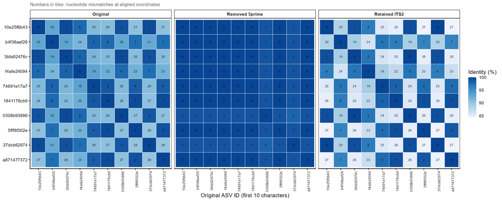

원래 Aureobasidium 후보 **10 ASV**를 확인했다. 기본 ITSx에서 원서열 **281 bp** 중 **109–281번 위치 (173 bp)**가 남았으며, 남은 구간은 모두 원서열과 **100% 일치**한다.

따라서 이 ASV들의 분류 변화는 남아 있는 염기에 오류가 생겼기 때문이 아니라, **분류기에 입력되는 구간이 바뀐 상황에서 발생했다.** 다만 이 정렬만으로 원래 Aureobasidium 동정이 맞는지, 제거된 구간이 무엇인지, 어느 DB 분류가 정확한지는 확정할 수 없다. 원서열·제거 구간·남은 구간을 각각 reference/BLAST와 대조해야 한다. 특히 Fungi까지만 분류된 결과는 Aureobasidium이 아니라는 증명이 아니다.

## 7.8 결과 요약

입력 **1,855 ASV / 1,186,913 reads** 중 ITSx 기본은 **1,204 ASV / 1,024,785 reads (86.34%)**에 연결되었다. partial50은 **1,204 ASV**를 출력했다.

공통 ASV는 **1201개**, 기본 조건만의 ASV는 **3개 (497 reads)**, partial50만의 ASV는 **3개 (35 reads)**다. 동일한 총 ASV 수라도 구성은 다를 수 있다.

ASV별 원서열·추출서열·경계·count와 샘플별 회수율, taxonomy 전환 및 그림은 `Results/01g_single_UNITE_database_comparison/ITSx_ASV_audit/`에 저장했다.

# 8 해석

1. **All-euk DB의 핵심 이점은 non-fungal competitor를 reference에 포함한다는 점이다.** fungi-only DB의 `Fungi_k`는 진균 확정이 아니라 진균 DB 안에서 더 깊게 내려가지 못한 결과일 수 있다.
2. **Raphanus ASV는 All-euk 분류와 BLAST가 일치한다.** 이 ASV는 downstream fungal community 분석에서 제외할 근거가 강하다.
3. **All-euk DB에서도 Fungi로 유지되는 Malassezia/Aureobasidium 계열은 단순히 broad DB 사용만으로 사라지지 않는다.** 다만 species 수준의 정확성은 별도 BLAST가 필요하다.
4. **Cutadapt와 ITSxpress의 원래 read-retention 차이는 database 변경으로 해결되지 않는다.** DB는 이미 생성된 ASV의 label과 fungal filtering을 바꾸지만, ITSxpress 단계에서 탈락한 read를 복구하지는 않는다.
5. **Cutadapt에서는 off-target 검출이 특히 중요하다.** 더 많은 read와 긴 ASV를 보존하는 장점과 non-fungal amplicon을 함께 보존하는 단점이 동시에 존재한다.
6. **ITSxpress 결과도 All-euk DB로 audit해야 한다.** ITS boundary를 통과했다는 사실만으로 모든 ASV가 진균임을 보장하지 않는다.

# 9 다음 분석

- All-euk DB에서 non-fungal로 분류된 고풍부 ASV의 batch BLAST
- True sample에서 풍부하지만 여전히 `Fungi_k` 또는 낮은 rank로 남은 ASV의 개별 BLAST
- All-euk fungal filtering 전후 alpha diversity와 Aitchison beta diversity 민감도 비교
- Control type별 non-fungal fraction 및 반복 검출 ASV 확인
- 최종적으로 `99% fungi-only` 대 `99% all-euk`, 또는 `dynamic fungi-only` 대 `dynamic all-euk`처럼 clustering을 맞춘 비교를 추가하여 scope 효과를 분리

# 10 재현 파일

- 분석 코드: `Results/01g_single_UNITE_database_comparison/01g_single_UNITE_database_comparison.R`
- 요약 CSV: `Results/01g_single_UNITE_database_comparison/01_method_database_summary.csv`
- Rank별 label 변화: `Results/01g_single_UNITE_database_comparison/04b_rank_change_fraction.csv`
- `Fungi_k`/`Ascomycota_p` 재분류: `Results/01g_single_UNITE_database_comparison/04d_Fungi_k_Ascomycota_p_destination_summary.csv`
- 재분류 ASV: `Results/01g_single_UNITE_database_comparison/05_top_reclassified_ASVs.csv`
- 전체 True sample taxonomy flow: `Results/01g_single_UNITE_database_comparison/09b_all_true_sample_taxonomy_flow.csv`
- 전체 True sample Family-level flow: `Results/01g_single_UNITE_database_comparison/09c_all_true_sample_family_flow.csv`

## 10.1 한계

- 기존 DB와 새 DB는 taxon scope와 clustering scheme이 동시에 다르다.
- Naive Bayes classifier 결과는 reference coverage와 training composition에 의존한다.
- All-euk DB의 species label도 BLAST 또는 curated reference validation 없이 확정적인 종 동정으로 사용하지 않는다.
- 이번 보고서는 taxonomy database effect 분석이며 contamination 제거 또는 biological differential-abundance 분석이 아니다.